# Analysis of Replase-Free Survival (RFS) Time for (E1684, E1690) Data Sets

# Summary of Baseline Covariate

```r
## load data
hist <- E1684
curr <- E1690

## replace 0 failure times with 0.50 days
hist <- hist %>% mutate(failtime = if_else(failtime == 0, 0.50/365.25, failtime)) # 1 subject w/ failtime = 0
curr <- curr %>% mutate(failtime = if_else(failtime == 0, 0.50/365.25, failtime)) # 10 subjects w/ failtime = 0

#no subjects in current data w/ survtime = 0

## Center and scale age based on current data
age_stats <- with(curr, c('mean' = mean(age), 'sd' = sd(age)))
hist$cage <- ( hist$age - age_stats['mean'] ) / age_stats['sd']
curr$cage <- ( curr$age - age_stats['mean'] ) / age_stats['sd']
```

```r
library(gtsummary)
## create summary table
df       <- rbind(curr, hist) %>%
  mutate(
    Treatment = case_when(
      treatment == 1 ~ "Treatment",
      TRUE ~ "Control"
    ),
    Sex = factor(sex, levels = c(0, 1), labels = c("Male", "Female")),
    `Having > 1 cancerous lymph node` = case_when(
      `node_bin` == 1 ~ "Yes (> 1 node)",
      TRUE ~ "No (0 or 1 node)"
    ),
    Age = age,
    `Standardized Age` = cage
  )
df$Study <- rep(c("E1690", "E1684"), times = c(nrow(curr), nrow(hist)))

tab <- df %>%
  select(all_of(c("Treatment", "Sex", "Age", "Standardized Age", "Having > 1 cancerous lymph node", "Study"))) %>%
  tbl_summary(
    by = Study,
    statistic = list(
      all_continuous() ~ "{mean} ({sd})",
      all_categorical() ~ "{n} ({p}%)"
    ),
    digits = all_continuous() ~ 2
  ) %>%
  modify_header(label ~ "**Variable**",
                `stat_1` ~ "E1684, N = 262",
                `stat_2` ~ "E1690, N = 426")
tab
```

| **Variable** | E1684, N = 262<sup>1</sup> | E1690, N = 426<sup>1</sup> |
| --- | --- | --- |
| Treatment |  |  |
| Control | 128 (49%) | 211 (50%) |
| Treatment | 134 (51%) | 215 (50%) |
| Sex |  |  |
| Male | 158 (60%) | 267 (63%) |
| Female | 104 (40%) | 159 (37%) |
| Age | 47.02 (13.08) | 47.93 (13.17) |
| Standardized Age | -0.07 (0.99) | 0.00 (1.00) |
| Having > 1 cancerous lymph node |  |  |
| No (0 or 1 node) | 31 (12%) | 112 (26%) |
| Yes (> 1 node) | 231 (88%) | 314 (74%) |

<sup>1</sup> n (%); Mean (SD)

```r
# show_header_names(tab)
```

# Frequentist Analysis

[figure not shown]

```r
## formula for current and historical data (Cox PH model)
fmla     <- Surv(failtime, failcens) ~ treatment + sex + cage + node_bin

## fit proportional hazards models on E1690 and E1684 data
fit      <- coxph(formula = fmla, data = curr)
fit.hist <- coxph(formula = fmla, data = hist)

summary(fit)
```

```
Call:
coxph(formula = fmla, data = curr)

  n= 426, number of events= 240

              coef exp(coef) se(coef)      z Pr(>|z|)
treatment -0.21306   0.80810  0.13013 -1.637 0.101565
sex       -0.21545   0.80618  0.13744 -1.568 0.116990
cage       0.15210   1.16428  0.06632  2.293 0.021823 *
node_bin   0.54687   1.72784  0.16020  3.414 0.000641 ***
---
Signif. codes:  0 ‘***’ 0.001 ‘**’ 0.01 ‘*’ 0.05 ‘.’ 0.1 ‘ ’ 1

          exp(coef) exp(-coef) lower .95 upper .95
treatment    0.8081     1.2375    0.6262     1.043
sex          0.8062     1.2404    0.6158     1.055
cage         1.1643     0.8589    1.0224     1.326
node_bin     1.7278     0.5788    1.2622     2.365

Concordance= 0.587  (se = 0.019 )
Likelihood ratio test= 20.79  on 4 df,   p=3e-04
Wald test            = 20  on 4 df,   p=5e-04
Score (logrank) test = 20.2  on 4 df,   p=5e-04
```

```r
summary(fit.hist)
```

```
Call:
coxph(formula = fmla, data = hist)

  n= 262, number of events= 175

              coef exp(coef) se(coef)      z Pr(>|z|)
treatment -0.43914   0.64459  0.15290 -2.872  0.00408 **
sex       -0.02483   0.97548  0.15537 -0.160  0.87304
cage       0.09620   1.10098  0.07714  1.247  0.21235
node_bin   0.75756   2.13306  0.27790  2.726  0.00641 **
---
Signif. codes:  0 ‘***’ 0.001 ‘**’ 0.01 ‘*’ 0.05 ‘.’ 0.1 ‘ ’ 1

          exp(coef) exp(-coef) lower .95 upper .95
treatment    0.6446     1.5514    0.4777    0.8698
sex          0.9755     1.0251    0.7194    1.3227
cage         1.1010     0.9083    0.9465    1.2807
node_bin     2.1331     0.4688    1.2372    3.6775

Concordance= 0.606  (se = 0.021 )
Likelihood ratio test= 15.97  on 4 df,   p=0.003
Wald test            = 14.85  on 4 df,   p=0.005
Score (logrank) test = 15.09  on 4 df,   p=0.005
```

```r
## combine Cox PH model estimates with summary of baseline covariates
tab.E1690.coxph <- coxph(
  Surv(failtime, failcens) ~ Treatment + Sex + `Standardized Age` + `Having > 1 cancerous lymph node`,
  data = df[df$Study == "E1690", ]
) %>%
  tbl_regression(
    label = list(
      `Sex` ~ "Sex",
      `Standardized Age` ~ "Standardized Age",
      `Having > 1 cancerous lymph node` ~ "Having > 1 cancerous lymph node"
    ),
    exponentiate = TRUE
  ) %>%
  modify_header(label ~ "**Variable**")  %>%
  modify_column_hide(columns = p.value)

tab.E1684.coxph <- coxph(
  Surv(failtime, failcens) ~ Treatment + Sex + `Standardized Age` + `Having > 1 cancerous lymph node`,
  data = df[df$Study == "E1684", ]
) %>%
  tbl_regression(
    label = list(
      `Sex` ~ "Sex",
      `Standardized Age` ~ "Standardized Age",
      `Having > 1 cancerous lymph node` ~ "Having > 1 cancerous lymph node"
    ),
    exponentiate = TRUE
  ) %>%
  modify_header(label ~ "**Variable**") %>%
  modify_column_hide(columns = p.value)

library(gt)
tab.combined <- tbl_merge(
  tbls = list(tab, tab.E1684.coxph, tab.E1690.coxph),
  tab_spanner = c("**Summary Statistics**", "**Cox PH Model for E1684**", "**Cox PH Model for E1690**")
) %>%
  as_gt() %>%
  #gt::tab_source_note("Cox PH Model: Cox proportional hazards (PH) regression model including Treatment, Sex, Standardized Age, and Having > 1 cancerous lymph node.")
  gt::tab_footnote(
    footnote = "Cox proportional hazards (PH) regression model including Treatment, Sex, Standardized Age, and Having > 1 cancerous lymph node.",
    locations = cells_column_spanners(c("**Cox PH Model for E1684**", "**Cox PH Model for E1690**"))
  )

#tab.combined %>%
#  gtsave(filename = "tab1_summary_stats.png", path = "/Users/xinxin/Documents/UNC/Dissertation/super prior/Code/Figures")
tab.combined
```

| **Variable** | **Summary Statistics** E1684, N = 262<sup>2</sup> | **Summary Statistics** E1690, N = 426<sup>2</sup> | **Cox PH Model for E1684**<sup>1</sup> **HR**<sup>3</sup> | **Cox PH Model for E1684**<sup>1</sup> **95% CI**<sup>3</sup> | **Cox PH Model for E1690**<sup>1</sup> **HR**<sup>3</sup> | **Cox PH Model for E1690**<sup>1</sup> **95% CI**<sup>3</sup> |
| --- | --- | --- | --- | --- | --- | --- |
| Treatment |  |  |  |  |  |  |
| Control | 128 (49%) | 211 (50%) | — | — | — | — |
| Treatment | 134 (51%) | 215 (50%) | 0.64 | 0.48, 0.87 | 0.81 | 0.63, 1.04 |
| Sex |  |  |  |  |  |  |
| Male | 158 (60%) | 267 (63%) | — | — | — | — |
| Female | 104 (40%) | 159 (37%) | 0.98 | 0.72, 1.32 | 0.81 | 0.62, 1.06 |
| Age | 47.02 (13.08) | 47.93 (13.17) |  |  |  |  |
| Standardized Age | -0.07 (0.99) | 0.00 (1.00) | 1.10 | 0.95, 1.28 | 1.16 | 1.02, 1.33 |
| Having > 1 cancerous lymph node |  |  |  |  |  |  |
| No (0 or 1 node) | 31 (12%) | 112 (26%) | — | — | — | — |
| Yes (> 1 node) | 231 (88%) | 314 (74%) | 2.13 | 1.24, 3.68 | 1.73 | 1.26, 2.37 |

<sup>1</sup> Cox proportional hazards (PH) regression model including Treatment, Sex, Standardized Age, and Having > 1 cancerous lymph node.  
<sup>2</sup> n (%); Mean (SD)  
<sup>3</sup> HR = Hazard Ratio, CI = Confidence Interval

# Bayesian Analysis

We fit a proportional hazards (PH) model with a piece-wise constant baseline hazards using the equivalent Poisson likelihood. We assumed 5 intervals for the piece-wise constant baseline hazards. The cut points of these intervals were selected such that each interval consists of about the same number of events/relapses.

We consider the following list of priors for analysis: the reference prior, Bayesian hierarchical model (BHM), commensurate prior, power prior, normalized power prior (NPP), latent exchangeability prior (LEAP), and propensity score-integrated power prior (PSIPP). For historical data priors, information are borrowed on both the treatment and control arms.

The goal is to compare the 2-year survival probabilities between the treatment and control arm.

```r
results.dir <- "~/Documents/UNC/Dissertation/super prior/Code/Analysis/Results"
file.list   <- list.files(results.dir, pattern = 'nintervals_5.rds')
file.list   <- file.list[-c(3,6,7)] ## rm pp w/ a0 = 0.2 and 0.8 as well as psipp for now

## obtain cut points for intervals
nbreaks <- 5
probs   <- 1:nbreaks / nbreaks
breaks  <- curr %>%
  filter(failcens == 1) %>%
  reframe(quant = quantile(failtime, probs = probs)) %>%
  unlist
breaks  <- breaks[-nbreaks]
```

## Predicted Difference in 2-Year Survival Probabilities from Individual Priors

```r
surv.diff.list <- list(length = length(file.list))
loo.list       <- list(length = length(file.list))
logml.list     <- list(length = length(file.list))

time.list     <- seq(0, 7, length = 100)
surv.prob.trt <- list(length = length(file.list))
surv.prob.ctl <- list(length = length(file.list))

for (i in 1:length(file.list)) {
  res.i         <- readRDS(file.path(results.dir, file.list[i]))
  loo.list[[i]] <- res.i$res.loo
  logml.list[[i]] <- res.i$res.logml

  d     <- res.i$draws
  prior <- res.i$scen$priors

  if ( prior == "psipp" ){
    d.surv.diff <- get.surv.diff.2yr.psipp(
      post.samples = d,
      breaks = breaks
    )
    surv.prob <- sapply(time.list, function(x){
      res.surv <- get.surv.prob.psipp(
        t = x,
        post.samples = d,
        breaks = breaks
      )
      return(
        c("trt" = mean(res.surv$surv.trt),
          "ctl" = mean(res.surv$surv.ctl))
      )
    })

  }else{
    d.surv.diff <- get.surv.diff.2yr.glm(
       post.samples = d,
       data = curr,
       breaks = breaks
    )
    surv.prob <- sapply(time.list, function(x){
      res.surv <- get.surv.prob.glm(
        t = x,
        post.samples = d,
        data = curr,
        breaks = breaks
      )
      return(
        c("trt" = mean(res.surv$surv.trt),
          "ctl" = mean(res.surv$surv.ctl))
      )
    })

  }

  surv.diff.list[[i]] <- d.surv.diff
  surv.prob.trt[[i]]  <- surv.prob["trt", ]
  surv.prob.ctl[[i]]  <- surv.prob["ctl", ]

  estim.i <- round(c(mean = mean(d.surv.diff), sd = sd(d.surv.diff),
                     quantile2(d.surv.diff, probs = c(0.5, 0.025, 0.975))), 3)
  prior.i <- prior

  if( i == 1 ){
    estim  <- estim.i
    priors <- prior.i
  }else{
    estim  <- rbind(estim, estim.i)
    priors <- c(priors, prior.i)
  }
  print( paste0("######################## Completed iteration ", i, "######################## "))

  temp <- list(
    loo.list = loo.list,
    surv.diff.list = surv.diff.list,
    surv.prob.ctl = surv.prob.ctl,
    surv.prob.trt = surv.prob.trt,
    logml.list = logml.list,
    estim = estim,
    priors = priors
  )
  saveRDS(temp,
          "~/Documents/UNC/Dissertation/super prior/Code/Analysis/compiled_analysis_results.rds")
}
rm(temp)
```

[output not shown]

For NPP, the posterior mean of $a_0$ is about 0.5781.

```r
res.npp <- readRDS(file.path(results.dir, "PWE_id_116_npp_nintervals_5.rds"))
res.npp$draws %>%
  summarize_draws(mean, sd, ~quantile2(.x, probs = c(0.025, 0.975))) %>%
  filter(variable == "a0_hist_1")
```

| variable | mean | sd | q2.5 | q97.5 |
| --- | --- | --- | --- | --- |
| a0_hist_1 | 0.5781267 | 0.2191599 | 0.1921756 | 0.9666672 |

For LEAP, the posterior mean of the probability of subjects in historical data being exchangeable with those in current data is about 0.857.

```r
res.leap <- readRDS(file.path(results.dir, "PWE_id_102_leap_nintervals_5.rds"))
res.leap$draws %>%
  summarize_draws(mean, sd, ~quantile2(.x, probs = c(0.025, 0.975))) %>%
  filter(variable == "gamma")
```

| variable | mean | sd | q2.5 | q97.5 |
| --- | --- | --- | --- | --- |
| gamma | 0.857236 | 0.05743308 | 0.7437063 | 0.9752389 |

## Weights from model-averaging priors

```r
## BMA weights
logml.vals <- lapply(logml.list, function(l){
  l$logml
})
logml.vals <- unlist(logml.vals)
post.prob <- bridgesampling::post_prob(logml.vals)


lpd_point  <- sapply(loo.list, function(l){
    l$pointwise[,"elpd_loo"]
})

pbma_wts     <- pseudobma_weights(lpd_point, BB=FALSE)
pbma_BB_wts  <- pseudobma_weights(lpd_point) # default is BB=TRUE
stacking_wts <- stacking_weights(lpd_point)

wts.tab <- data.frame(
  prior = estim$prior,
  "BMA" = round(post.prob, 3),
  "Pseudo-BMA" = round(pbma_wts, 3),
  "Pseudo-BMA w/ BB" = round(pbma_BB_wts, 3),
  "Stacking" = round(stacking_wts, 3)
)
rownames(wts.tab) <- NULL
colnames(wts.tab)[3:4] <- c("Pseudo-BMA", "Pseudo-BMA w/ BB")
wts.tab
```

| prior | BMA | Pseudo-BMA | Pseudo-BMA w/ BB | Stacking |
| --- | --- | --- | --- | --- |
| leap | 0.000 | 0.112 | 0.135 | 0.000 |
| npp | 0.389 | 0.218 | 0.201 | 0.000 |
| pp_0.5 | 0.592 | 0.288 | 0.254 | 0.905 |
| ref | 0.000 | 0.096 | 0.147 | 0.095 |
| bhm | 0.016 | 0.156 | 0.137 | 0.000 |
| commensurate | 0.003 | 0.130 | 0.125 | 0.000 |

## Predicted Difference in 2-Year Survival Probabilities from All Methods

| prior | mean | sd | q50 | q2.5 | q97.5 | prob_greater_0 |
| --- | --- | --- | --- | --- | --- | --- |
| leap | 0.090 | 0.041 | 0.090 | 0.007 | 0.168 | 0.983 |
| npp | 0.109 | 0.038 | 0.109 | 0.032 | 0.183 | 0.997 |
| pp_0.5 | 0.108 | 0.038 | 0.108 | 0.033 | 0.181 | 0.998 |
| ref | 0.086 | 0.044 | 0.086 | -0.001 | 0.171 | 0.974 |
| bhm | 0.101 | 0.041 | 0.101 | 0.017 | 0.180 | 0.991 |
| commensurate | 0.092 | 0.042 | 0.092 | 0.010 | 0.173 | 0.985 |
| BMA | 0.108 | 0.038 | 0.108 | 0.032 | 0.182 | 0.997 |
| Pseudo-BMA | 0.101 | 0.041 | 0.102 | 0.019 | 0.179 | 0.991 |
| Pseudo-BMA w/ BB | 0.100 | 0.041 | 0.101 | 0.016 | 0.179 | 0.990 |
| Stacking | 0.106 | 0.039 | 0.106 | 0.028 | 0.180 | 0.996 |

```r
estim_all[!estim_all$prior %in% c("Pseudo-BMA", "Pseudo-BMA w/ BB"), ]
```

|  | prior | mean | sd | q50 | q2.5 | q97.5 | prob_greater_0 |
| --- | --- | --- | --- | --- | --- | --- | --- |
| 1 | leap | 0.090 | 0.041 | 0.090 | 0.007 | 0.168 | 0.983 |
| 2 | npp | 0.109 | 0.038 | 0.109 | 0.032 | 0.183 | 0.997 |
| 3 | pp_0.5 | 0.108 | 0.038 | 0.108 | 0.033 | 0.181 | 0.998 |
| 4 | ref | 0.086 | 0.044 | 0.086 | -0.001 | 0.171 | 0.974 |
| 5 | bhm | 0.101 | 0.041 | 0.101 | 0.017 | 0.180 | 0.991 |
| 6 | commensurate | 0.092 | 0.042 | 0.092 | 0.010 | 0.173 | 0.985 |
| 7 | BMA | 0.108 | 0.038 | 0.108 | 0.032 | 0.182 | 0.997 |
| 10 | Stacking | 0.106 | 0.039 | 0.106 | 0.028 | 0.180 | 0.996 |

```r
tab <- estim_tab %>%
  dplyr::select(prior, mean, CI, weights_BMA, weights_stacking) %>%
  kable("latex",
      col.names = c('Method', 'Mean', "SD", '$95\\%$ CI', 'BMA Weight', 'Stacking Weight'),
      digits = ndigits, align = 'c',
      booktabs=TRUE, escape = FALSE,
      caption = 'Posterior Estimates of $\\Delta$ with Model Weights from BMA and Stacking')
```

```
Error in dimnames(x) <- dn :
  length of 'dimnames' [2] not equal to array extent
```

## Posterior Density Plot of Predicted Difference in 2-Year Survival Probabilities

1. Posterior densities from PP with $a_0 = 0.5$, NPP, and BMA are quite similar to each other.

```r
surv_diff_df           <- cbind(d.surv.diff.mtx, d.surv.diff.bma, d.surv.diff.pbma, d.surv.diff.pbma.BB, d.surv.diff.stacking)
colnames(surv_diff_df) <- c(estim$prior, "Ensemble (BMA Weights)", "Ensemble (Pseudo-BMA Weights)", "Ensemble (Pseudo-BMA + BB Weights)", "Ensemble (Stacking Weights)")
colnames(surv_diff_df) <- recode(colnames(surv_diff_df),
                                 ref = "Reference",
                                 leap = "LEAP",
                                 npp = "NPP",
                                 `pp_0.5` = "PP",
                                 bhm = "BHM",
                                 commensurate = "Commensurate")

surv_diff_df           <- as.data.frame(surv_diff_df)
surv_diff_df_long      <- surv_diff_df %>%
  pivot_longer(
    cols = all_of(colnames(surv_diff_df)),
    names_to = "method",
    values_to = "estimate"
  )
surv_diff_df_long$method <- factor(surv_diff_df_long$method,
                                  levels = c("Reference", "BHM", "Commensurate", "LEAP", "NPP",
                                             "PP", "Ensemble (BMA Weights)",
                                             "Ensemble (Pseudo-BMA Weights)",
                                             "Ensemble (Pseudo-BMA + BB Weights)",
                                             "Ensemble (Stacking Weights)"),
                                  ordered = T)
```

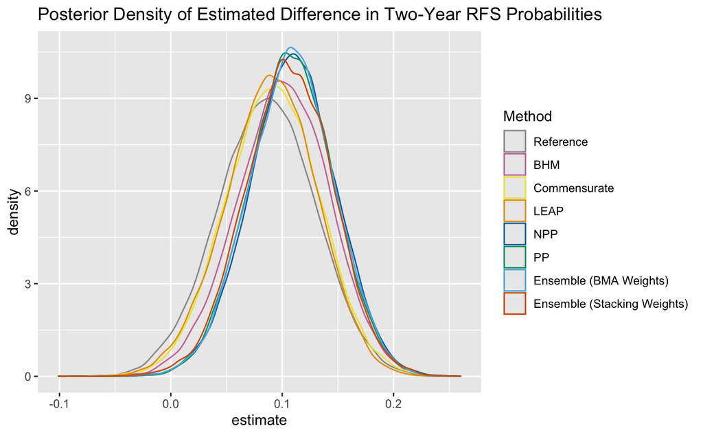

```r
cbPalette <- c("#999999", "#CC79A7", "#F0E442", "#E69F00", "#0072B2", "#009E73", "#56B4E9", "#D55E00")

surv_diff_df_long %>%
  filter(! method %in% c("Ensemble (Pseudo-BMA Weights)", "Ensemble (Pseudo-BMA + BB Weights)")) %>%
  ggplot(aes(x=estimate, color = method)) +
  geom_density() +
  scale_colour_manual(values= cbPalette) +
  labs(title = "Posterior Density of Estimated Difference in Two-Year RFS Probabilities",
       color = "Method")
```

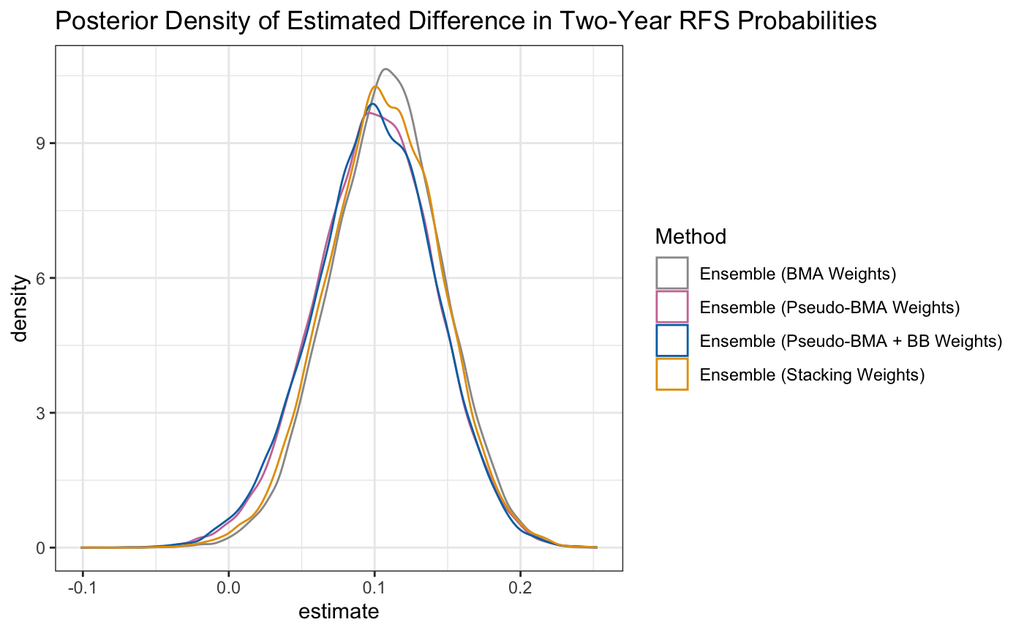

```r
surv_diff_df_long %>%
  filter( method %in% c("Ensemble (BMA Weights)", "Ensemble (Pseudo-BMA Weights)", "Ensemble (Pseudo-BMA + BB Weights)", "Ensemble (Stacking Weights)")) %>%
  ggplot(aes(x=estimate, color = method)) +
  geom_density() +
  scale_colour_manual(values=  c("#999999", "#CC79A7", "#0072B2", "#E69F00")) +
  labs(title = "Posterior Density of Estimated Difference in Two-Year RFS Probabilities",
       color = "Method") +
  theme_bw()
```

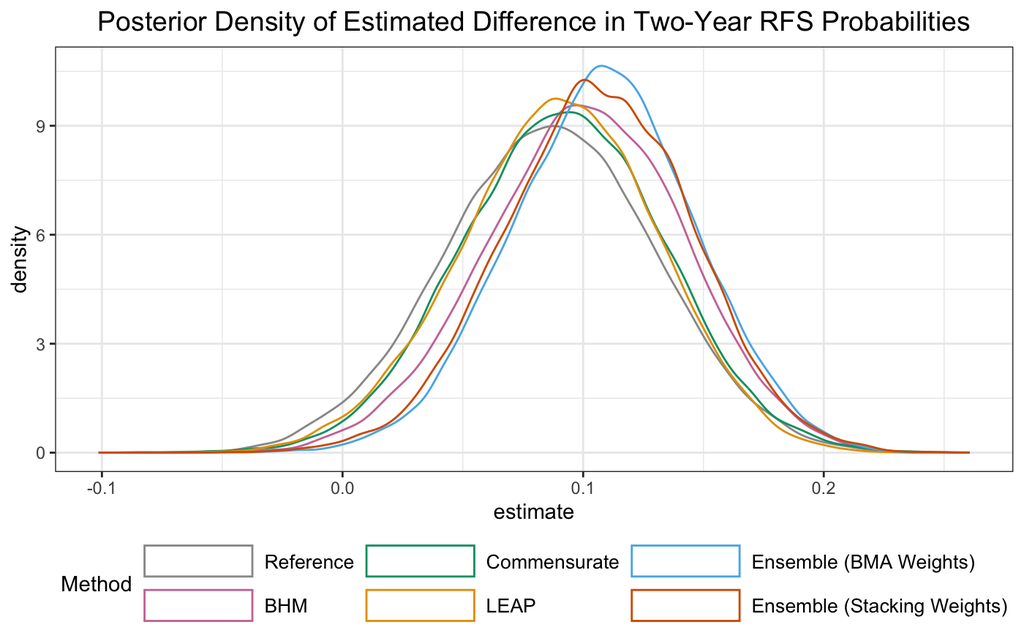

```r
cbPalette <- c("#999999", "#CC79A7", "#009E73", "#E69F00","#56B4E9", "#D55E00")

surv_diff_df_long %>%
  filter(! method %in% c("Ensemble (Pseudo-BMA Weights)", "Ensemble (Pseudo-BMA + BB Weights)"
                         , "NPP", "PP")) %>%
  ggplot(aes(x=estimate, color = method)) +
  geom_density() +
  scale_colour_manual(values= cbPalette) +
  labs(title = "Posterior Density of Estimated Difference in Two-Year RFS Probabilities",
       color = "Method") +
  theme_bw() +
      theme(legend.position = "bottom",
            legend.box = "vertical",
            legend.text=element_text(size=10),
            legend.key.width= unit(2, 'cm'),
            legend.margin=margin(),
            strip.text.x = element_text(size = 10),
            strip.text.y = element_text(size = 10),
            plot.title = element_text(hjust = 0.5, size = 14))
```

### Posterior Density Plot for PSIPP per Stratum

```r
#' function to predict survival probability at t years for treated and untreated groups for each stratum under PSIPP
#'
get.surv.prob.psipp.stratum <- function(
    t,
    post.samples,
    breaks
){
  J          = length(breaks) + 1
  stan.data  = attr(post.samples, 'data')
  p          = stan.data$p
  K          = stan.data$K
  X          = stan.data$X
  beta       = suppressWarnings(
    as.matrix( post.samples[, paste0( "treatment", '_stratum_', 1:K ), drop=F] )
  )

  log_hazard = suppressWarnings(
    as.matrix( post.samples[, paste0( colnames(X)[-which(colnames(X) == "treatment")], '_stratum_', rep(1:K, each = p-1) ), drop=F] )
  )
  interval_names = colnames(X)[-which(colnames(X) == "treatment")]

  ## interval index for which the time t belongs to
  interval.id = findInterval(t, c(0, breaks, Inf), left.open = TRUE)
  if( t == 0 ){
    interval.id = 1
  }

  breaks.new              = (c(breaks, Inf))[1:interval.id]
  breaks.new[interval.id] = t
  interval.length         = breaks.new - c(0, breaks.new[-interval.id])

  ## compute cumulative baseline hazard at t years for each stratum
  H = sapply(1:K, function(k){
    log_hazard_stratum = log_hazard[, paste0(interval_names, '_stratum_', k)]
    log_hazard_stratum = log_hazard_stratum[, 1] + cbind(0, log_hazard_stratum[, 2:J])
    hazard_stratum     = exp(log_hazard_stratum) ## baseline hazards

    H_stratum          = hazard_stratum[, 1:interval.id, drop = F] %r*% interval.length
    if( interval.id != 1 ){
      H_stratum        = t( apply(H_stratum, 1, cumsum) ) ## cumulative baseline hazard
    }
    H_stratum        = H_stratum[, interval.id]
    return( H_stratum)
  })

  ## predicted t-year survival probability for untreated for each stratum
  S.ctl = lapply(1:K, function(k){
    H_stratum     = H[, k]
    S_ctl_stratum = exp( -H_stratum )
    return(S_ctl_stratum)
  }
  )
  S.ctl = do.call(cbind, S.ctl)

  ## predicted t-year survival probability for untreated for each stratum
  S.trt = lapply(1:K, function(k){
    H_stratum     = H[, k]
    beta_stratum  = beta[, paste0( 'treatment_stratum_', k)]
    S_trt_stratum = exp( -H_stratum * exp(beta_stratum) )
    return(S_trt_stratum)
  }
  )
  S.trt = do.call(cbind, S.trt)

  return(
    list(
      surv.trt.stratum = S.trt,
      surv.ctl.stratum = S.ctl
    )
  )
}

#' function to estimate the treatment effect (difference in 2-year survival probability between treated and untreated) for each stratum,
#' i.e., P(T > 2 | A = 1) - P(T > 2 | A = 0), for PSIPP
get.surv.diff.2yr.psipp.stratum <- function(
    post.samples,
    breaks
) {
  surv.list = get.surv.prob.psipp.stratum(
    t = 2,
    post.samples = post.samples,
    breaks = breaks
  )
  surv.diff  = surv.list$surv.trt.stratum - surv.list$surv.ctl.stratum
  return(surv.diff)
}
```

```r
res.psipp <- readRDS(file.path(results.dir, "PWE_id_60_psipp_nintervals_5.rds"))

d.surv.diff.psipp.stratum <- get.surv.diff.2yr.psipp.stratum(
  post.samples = res.psipp$draws,
  breaks = breaks
)
colnames(d.surv.diff.psipp.stratum) <- paste0("Stratum ", 1:ncol(d.surv.diff.psipp.stratum))

surv_diff_df_psipp      <- as.data.frame(d.surv.diff.psipp.stratum)
surv_diff_df_psipp_long <- surv_diff_df_psipp %>%
  pivot_longer(
    cols = all_of(colnames(surv_diff_df_psipp)),
    names_to = "strata",
    values_to = "estimate"
  )
surv_diff_df_psipp_long$strata <- factor(surv_diff_df_psipp_long$strata,
                                         levels = paste0("Stratum ", 1:ncol(d.surv.diff.psipp.stratum)),
                                         ordered = T)

ggplot(surv_diff_df_psipp_long, aes(x=estimate, col = strata, linetype = strata)) +
  geom_density() +
  scale_colour_manual(values= c("#999999", "#56B4E9", "#CC79A7", "orange")) +
  labs(title = "Posterior Density of Predicted Difference in 2-Year Survival Probabilities",
       subtitle = "for Each Stratum under PSIPP")
```

[output not shown]

## Predicted Survival Probabilities

```r
surv.prob.ctl.long <- lapply(1:length(priors), function(i){
  df = cbind(prob = surv.prob.ctl[[i]], trt = 0, time = time.list) %>% as.data.frame()
  df$priors = priors[[i]]
  return(df)
})
surv.prob.ctl.long <- do.call(rbind, surv.prob.ctl.long)

surv.prob.trt.long <- lapply(1:length(priors), function(i){
  df = cbind(prob = surv.prob.trt[[i]], trt = 1, time = time.list) %>% as.data.frame()
  df$priors = priors[[i]]
  return(df)
})
surv.prob.trt.long <- do.call(rbind, surv.prob.trt.long)

surv.prob     <- rbind(surv.prob.ctl.long, surv.prob.trt.long) %>% as.data.frame()
surv.prob$trt <- as.factor(surv.prob$trt)

surv.prob %>%
  ggplot(aes(x = time, y = prob, color = trt)) +
  geom_line() +
  #geom_point() +
  labs(x = 'time') +
  facet_wrap(~priors) +
  labs(title = "Predicted Survival Probabilities") +
  theme_bw() +
  theme(plot.title = element_text(hjust = 0.5))
```

[output not shown]

### Predicted Survival Probabilities for PSIPP per Stratum

```r
surv.prob.stratum <- lapply(time.list, function(x){
  res.surv = get.surv.prob.psipp.stratum(
    t = x,
    post.samples = res.psipp$draws,
    breaks = breaks
  )
  df = rbind(colMeans(res.surv$surv.trt.stratum),
              colMeans(res.surv$surv.ctl.stratum)) %>%
    as.data.frame()
  colnames(df) = paste0("Stratum ", 1:ncol(df))
  df$trt  = c(1, 0)
  df$time = x
  return(df)
})
surv.prob.stratum      <- do.call(rbind, surv.prob.stratum)
surv.prob.stratum.long <- surv.prob.stratum %>%
  pivot_longer(
    cols = all_of(paste0("Stratum ", 1:(ncol(surv.prob.stratum)-2))),
    names_to = "strata",
    values_to = "prob"
  )
surv.prob.stratum.long$trt <- as.factor(surv.prob.stratum.long$trt)

surv.prob.stratum.long %>%
  ggplot(aes(x = time, y = prob, linetype = trt)) +
  geom_line() +
  #geom_point() +
  labs(x = 'time') +
  facet_wrap(~strata) +
  labs(title = "Predicted Survival Probabilities for Each Stratum under PSIPP", linetype = "Treatment") +
  theme_bw() +
  theme(plot.title = element_text(hjust = 0.5))
```

[output not shown]

```r
res.strata <- res.psipp$res.strata
res.strata.curr <- cbind(res.strata$data.list$curr, stratum = res.strata$strata.list$curr)

res.strata.curr %>%
  group_by(stratum) %>%
  summarise(mean_sex = mean(sex), mean_age = mean(age), mean_node_bin = mean(node_bin))
```

[output not shown]